# SPSS_Output_lesson15

[output not shown]

Log  
Log - Log - October 17, 2017

GET  
FILE='C:\MyGithub\N736Fall2017_lesson1415\helpmkh.sav'.  
DATASET NAME DataSet2 WINDOW=FRONT.  
DATASET ACTIVATE DataSet2.  
DATASET CLOSE DataSet1.  
* ==========================================  
* N736: Lesson 15  
* by Melinda Higgins, dated Oct 17. 2017  
*  
* be sure to load the helpmkh.sav dataset  
* ==========================================.  
* ==========================================  
* recode racegrp and substance variables  
* from character based to numerical coding with labels  
* ==========================================.  
AUTORECODE VARIABLES=racegrp substance  
/INTO racegrp_num substance_num  
/PRINT.  
racegrp into racegrp_num (Racial Group of Respondent)  
Old Value New Value Value Label  
black 1 black  
hispanic 2 hispanic  
other 3 other  
white 4 white  
substance into substance_num (Primary substance of abuse)  
Old Value New Value Value Label  
alcohol 1 alcohol  
cocaine 2 cocaine  
heroin 3 heroin  
* ==========================================  
* run a comparison to check recoding  
* ==========================================.  
FREQUENCIES VARIABLES=racegrp racegrp_num substance substance_num  
/ORDER=ANALYSIS.

Frequencies  
Frequencies - Statistics - October 17, 2017

StatisticsStatistics, table, 1 levels of column headers and 2 levels of row headers, table with 6 columns and 4 rows

|  |  | racegrp Racial Group of Respondent | racegrp_num Racial Group of Respondent | substance Primary substance of abuse | substance_num Primary substance of abuse |
| --- | --- | --- | --- | --- | --- |
| N | Valid | 453 | 453 | 453 | 453 |
|  | Missing | 0 | 0 | 0 | 0 |

Frequency Table  
Frequency Table - racegrp Racial Group of Respondent - October 17, 2017

racegrp Racial Group of Respondentracegrp Racial Group of Respondent, table, 1 levels of column headers and 2 levels of row headers, table with 6 columns and 7 rows

|  |  | Frequency | Percent | Valid Percent | Cumulative Percent |
| --- | --- | --- | --- | --- | --- |
| Valid | black | 211 | 46.6 | 46.6 | 46.6 |
|  | hispanic | 50 | 11.0 | 11.0 | 57.6 |
|  | other | 26 | 5.7 | 5.7 | 63.4 |
|  | white | 166 | 36.6 | 36.6 | 100.0 |
|  | Total | 453 | 100.0 | 100.0 |  |

Frequency Table  
Frequency Table - racegrp_num Racial Group of Respondent - October 17, 2017

racegrp_num Racial Group of Respondentracegrp_num Racial Group of Respondent, table, 1 levels of column headers and 2 levels of row headers, table with 6 columns and 7 rows

|  |  | Frequency | Percent | Valid Percent | Cumulative Percent |
| --- | --- | --- | --- | --- | --- |
| Valid | 1 black | 211 | 46.6 | 46.6 | 46.6 |
|  | 2 hispanic | 50 | 11.0 | 11.0 | 57.6 |
|  | 3 other | 26 | 5.7 | 5.7 | 63.4 |
|  | 4 white | 166 | 36.6 | 36.6 | 100.0 |
|  | Total | 453 | 100.0 | 100.0 |  |

Frequency Table  
Frequency Table - substance Primary substance of abuse - October 17, 2017

substance Primary substance of abusesubstance Primary substance of abuse, table, 1 levels of column headers and 2 levels of row headers, table with 6 columns and 6 rows

|  |  | Frequency | Percent | Valid Percent | Cumulative Percent |
| --- | --- | --- | --- | --- | --- |
| Valid | alcohol | 177 | 39.1 | 39.1 | 39.1 |
|  | cocaine | 152 | 33.6 | 33.6 | 72.6 |
|  | heroin | 124 | 27.4 | 27.4 | 100.0 |
|  | Total | 453 | 100.0 | 100.0 |  |

Frequency Table  
Frequency Table - substance_num Primary substance of abuse - October 17, 2017

substance_num Primary substance of abusesubstance_num Primary substance of abuse, table, 1 levels of column headers and 2 levels of row headers, table with 6 columns and 6 rows

|  |  | Frequency | Percent | Valid Percent | Cumulative Percent |
| --- | --- | --- | --- | --- | --- |
| Valid | 1 alcohol | 177 | 39.1 | 39.1 | 39.1 |
|  | 2 cocaine | 152 | 33.6 | 33.6 | 72.6 |
|  | 3 heroin | 124 | 27.4 | 27.4 | 100.0 |
|  | Total | 453 | 100.0 | 100.0 |  |

Log  
Log - Log - October 17, 2017

* ==========================================  
* merge hispanic (coded 2) and other (coded 3)  
* and create a 3-level race group  
* ==========================================.  
RECODE racegrp_num (1=1) (4=3) (2 thru 3=2) INTO racegrp3.  
VARIABLE LABELS racegrp3 'Race 3 Groups'.  
EXECUTE.  
* ==========================================  
* update labels with new numbering  
* ==========================================.  
* Define Variable Properties.  
*racegrp3.  
FORMATS racegrp3(F8.0).  
VALUE LABELS racegrp3  
1 'black'  
2 'hispanic or other'  
3 'white'.  
EXECUTE.  
* ==========================================  
* another quick check  
* ==========================================.  
FREQUENCIES VARIABLES=racegrp racegrp_num racegrp3  
/ORDER=ANALYSIS.

Frequencies  
Frequencies - Statistics - October 17, 2017

StatisticsStatistics, table, 1 levels of column headers and 2 levels of row headers, table with 5 columns and 4 rows

|  |  | racegrp Racial Group of Respondent | racegrp_num Racial Group of Respondent | racegrp3 Race 3 Groups |
| --- | --- | --- | --- | --- |
| N | Valid | 453 | 453 | 453 |
|  | Missing | 0 | 0 | 0 |

Frequency Table  
Frequency Table - racegrp Racial Group of Respondent - October 17, 2017

racegrp Racial Group of Respondentracegrp Racial Group of Respondent, table, 1 levels of column headers and 2 levels of row headers, table with 6 columns and 7 rows

|  |  | Frequency | Percent | Valid Percent | Cumulative Percent |
| --- | --- | --- | --- | --- | --- |
| Valid | black | 211 | 46.6 | 46.6 | 46.6 |
|  | hispanic | 50 | 11.0 | 11.0 | 57.6 |
|  | other | 26 | 5.7 | 5.7 | 63.4 |
|  | white | 166 | 36.6 | 36.6 | 100.0 |
|  | Total | 453 | 100.0 | 100.0 |  |

Frequency Table  
Frequency Table - racegrp_num Racial Group of Respondent - October 17, 2017

racegrp_num Racial Group of Respondentracegrp_num Racial Group of Respondent, table, 1 levels of column headers and 2 levels of row headers, table with 6 columns and 7 rows

|  |  | Frequency | Percent | Valid Percent | Cumulative Percent |
| --- | --- | --- | --- | --- | --- |
| Valid | 1 black | 211 | 46.6 | 46.6 | 46.6 |
|  | 2 hispanic | 50 | 11.0 | 11.0 | 57.6 |
|  | 3 other | 26 | 5.7 | 5.7 | 63.4 |
|  | 4 white | 166 | 36.6 | 36.6 | 100.0 |
|  | Total | 453 | 100.0 | 100.0 |  |

Frequency Table  
Frequency Table - racegrp3 Race 3 Groups - October 17, 2017

racegrp3 Race 3 Groupsracegrp3 Race 3 Groups, table, 1 levels of column headers and 2 levels of row headers, table with 6 columns and 6 rows

|  |  | Frequency | Percent | Valid Percent | Cumulative Percent |
| --- | --- | --- | --- | --- | --- |
| Valid | 1 black | 211 | 46.6 | 46.6 | 46.6 |
|  | 2 hispanic or other | 76 | 16.8 | 16.8 | 63.4 |
|  | 3 white | 166 | 36.6 | 36.6 | 100.0 |
|  | Total | 453 | 100.0 | 100.0 |  |

Log  
Log - Log - October 17, 2017

* ==========================================  
* create dummy variables for the 3 race groups  
* ==========================================.  
COMPUTE race_black=racegrp3 = 1.  
COMPUTE race_otherhisp=racegrp3 = 2.  
COMPUTE race_white=racegrp3 = 3.  
EXECUTE.  
* ==========================================  
* get means and SDs for sexrisk by the 3 racegroups  
* ==========================================.  
SORT CASES BY racegrp3.  
SPLIT FILE LAYERED BY racegrp3.  
FREQUENCIES VARIABLES=sexrisk  
/FORMAT=NOTABLE  
/NTILES=4  
/STATISTICS=STDDEV MINIMUM MAXIMUM MEAN  
/ORDER=ANALYSIS.

Frequencies  
Frequencies - Statistics - October 17, 2017

StatisticsStatistics, table, sexrisk Risk Assessment Battery (RAB) sex risk score - Baseline, 1 layers, 0 levels of column headers and 3 levels of row headers, table with 4 columns and 29 rows

| sexrisk Risk Assessment Battery (RAB) sex risk score - Baseline sexrisk Risk Assessment Battery (RAB) sex risk score - Baseline |  |  |  |
| --- | --- | --- | --- |
| 1 black | N | Valid | 211 |
|  |  | Missing | 0 |
|  | Mean |  | 5.23 |
|  | Std. Deviation |  | 2.732 |
|  | Minimum |  | 0 |
|  | Maximum |  | 14 |
|  | Percentiles | 25 | 3.00 |
|  |  | 50 | 5.00 |
|  |  | 75 | 7.00 |
| 2 hispanic or other | N | Valid | 76 |
|  |  | Missing | 0 |
|  | Mean |  | 4.22 |
|  | Std. Deviation |  | 2.765 |
|  | Minimum |  | 0 |
|  | Maximum |  | 14 |
|  | Percentiles | 25 | 3.00 |
|  |  | 50 | 4.00 |
|  |  | 75 | 5.00 |
| 3 white | N | Valid | 166 |
|  |  | Missing | 0 |
|  | Mean |  | 4.09 |
|  | Std. Deviation |  | 2.772 |
|  | Minimum |  | 0 |
|  | Maximum |  | 14 |
|  | Percentiles | 25 | 2.00 |
|  |  | 50 | 4.00 |
|  |  | 75 | 5.25 |

Log  
Log - Log - October 17, 2017

SPLIT FILE OFF.  
* ==========================================  
* run a one-way ANOVA and do post hoc tests,  
* no error rate adjustment (for the moment)  
* ==========================================.  
ONEWAY sexrisk BY racegrp3  
/STATISTICS DESCRIPTIVES EFFECTS HOMOGENEITY  
/MISSING ANALYSIS  
/POSTHOC=LSD ALPHA(0.05).

Oneway  
Oneway - Descriptives - October 17, 2017

DescriptivesDescriptives, table, sexrisk Risk Assessment Battery (RAB) sex risk score - Baseline, 1 layers, 2 levels of column headers and 2 levels of row headers, table with 11 columns and 10 rows

[output not shown]

Oneway  
Oneway - Test of Homogeneity of Variances - October 17, 2017

Test of Homogeneity of VariancesTest of Homogeneity of Variances, table, sexrisk Risk Assessment Battery (RAB) sex risk score - Baseline, 1 layers, 1 levels of column headers and 0 levels of row headers, table with 4 columns and 4 rows

| sexrisk Risk Assessment Battery (RAB) sex risk score - Baseline sexrisk Risk Assessment Battery (RAB) sex risk score - Baseline |  |  |  |
| --- | --- | --- | --- |
| Levene Statistic | df1 | df2 | Sig. |
| .430 | 2 | 450 | .651 |

Oneway  
Oneway - ANOVA - October 17, 2017

ANOVAANOVA, table, sexrisk Risk Assessment Battery (RAB) sex risk score - Baseline, 1 layers, 1 levels of column headers and 1 levels of row headers, table with 6 columns and 6 rows

| sexrisk Risk Assessment Battery (RAB) sex risk score - Baseline sexrisk Risk Assessment Battery (RAB) sex risk score - Baseline |  |  |  |  |  |
| --- | --- | --- | --- | --- | --- |
|  | Sum of Squares | df | Mean Square | F | Sig. |
| Between Groups | 136.144 | 2 | 68.072 | 8.989 | .000 |
| Within Groups | 3407.923 | 450 | 7.573 |  |  |
| Total | 3544.066 | 452 |  |  |  |

Post Hoc Tests  
Post Hoc Tests - Multiple Comparisons - October 17, 2017

Multiple ComparisonsMultiple Comparisons, table, Dependent Variable, sexrisk Risk Assessment Battery (RAB) sex risk score - Baseline, LSD, 1 layers, 2 levels of column headers and 2 levels of row headers, table with 7 columns and 12 rows

| sexrisk Risk Assessment Battery (RAB) sex risk score - Baseline sexrisk Risk Assessment Battery (RAB) sex risk score - Baseline LSD LSD |  |  |  |  |  |  |
| --- | --- | --- | --- | --- | --- | --- |
| (I) racegrp3 Race 3 Groups | (J) racegrp3 Race 3 Groups | Mean Difference (I-J) | Std. Error | Sig. | 95% Confidence Interval |  |
|  |  |  |  |  | Lower Bound | Upper Bound |
| 1 black | 2 hispanic or other | 1.004* | .368 | .007 | .28 | 1.73 |
|  | 3 white | 1.137* | .286 | .000 | .58 | 1.70 |
| 2 hispanic or other | 1 black | -1.004* | .368 | .007 | -1.73 | -.28 |
|  | 3 white | .133 | .381 | .727 | -.62 | .88 |
| 3 white | 1 black | -1.137* | .286 | .000 | -1.70 | -.58 |
|  | 2 hispanic or other | -.133 | .381 | .727 | -.88 | .62 |

*. The mean difference is significant at the 0.05 level.

Log  
Log - Log - October 17, 2017

* ==========================================  
* alternate code for one-way ANOVA  
* ==========================================.  
UNIANOVA sexrisk BY racegrp3  
/METHOD=SSTYPE(3)  
/INTERCEPT=INCLUDE  
/POSTHOC=racegrp3(LSD)  
/EMMEANS=TABLES(OVERALL)  
/EMMEANS=TABLES(racegrp3) COMPARE ADJ(LSD)  
/PRINT=ETASQ HOMOGENEITY DESCRIPTIVE  
/CRITERIA=ALPHA(.05)  
/DESIGN=racegrp3.

Univariate Analysis of Variance  
Univariate Analysis of Variance - Between-Subjects Factors - October 17, 2017

Between-Subjects FactorsBetween-Subjects Factors, table, 1 levels of column headers and 2 levels of row headers, table with 4 columns and 5 rows

|  |  | Value Label | N |
| --- | --- | --- | --- |
| racegrp3 Race 3 Groups | 1 | black | 211 |
|  | 2 | hispanic or other | 76 |
|  | 3 | white | 166 |

Univariate Analysis of Variance  
Univariate Analysis of Variance - Descriptive Statistics - October 17, 2017

Descriptive StatisticsDescriptive Statistics, table, Dependent Variable, sexrisk Risk Assessment Battery (RAB) sex risk score - Baseline, 1 layers, 1 levels of column headers and 1 levels of row headers, table with 4 columns and 7 rows

| sexrisk Risk Assessment Battery (RAB) sex risk score - Baseline sexrisk Risk Assessment Battery (RAB) sex risk score - Baseline |  |  |  |
| --- | --- | --- | --- |
| racegrp3 Race 3 Groups | Mean | Std. Deviation | N |
| 1 black | 5.23 | 2.732 | 211 |
| 2 hispanic or other | 4.22 | 2.765 | 76 |
| 3 white | 4.09 | 2.772 | 166 |
| Total | 4.64 | 2.800 | 453 |

Univariate Analysis of Variance  
Univariate Analysis of Variance - Levene's Test of Equality of Error Variances - October 17, 2017

Levene's Test of Equality of Error Variances<sup>a</sup>Levene's Test of Equality of Error Variances, table, Dependent Variable, sexrisk Risk Assessment Battery (RAB) sex risk score - Baseline, 1 layers, 1 levels of column headers and 0 levels of row headers, table with 4 columns and 6 rows

| sexrisk Risk Assessment Battery (RAB) sex risk score - Baseline sexrisk Risk Assessment Battery (RAB) sex risk score - Baseline |  |  |  |
| --- | --- | --- | --- |
| F | df1 | df2 | Sig. |
| .430 | 2 | 450 | .651 |

Tests the null hypothesis that the error variance of the dependent variable is equal across groups.  
a. Design: Intercept + racegrp3

Univariate Analysis of Variance  
Univariate Analysis of Variance - Tests of Between-Subjects Effects - October 17, 2017

Tests of Between-Subjects EffectsTests of Between-Subjects Effects, table, Dependent Variable, sexrisk Risk Assessment Battery (RAB) sex risk score - Baseline, 1 layers, 1 levels of column headers and 1 levels of row headers, table with 7 columns and 10 rows

| sexrisk Risk Assessment Battery (RAB) sex risk score - Baseline sexrisk Risk Assessment Battery (RAB) sex risk score - Baseline |  |  |  |  |  |  |
| --- | --- | --- | --- | --- | --- | --- |
| Source | Type III Sum of Squares | df | Mean Square | F | Sig. | Partial Eta Squared |
| Corrected Model | 136.144<sup>a</sup> | 2 | 68.072 | 8.989 | .000 | .038 |
| Intercept | 7665.676 | 1 | 7665.676 | 1012.216 | .000 | .692 |
| racegrp3 | 136.144 | 2 | 68.072 | 8.989 | .000 | .038 |
| Error | 3407.923 | 450 | 7.573 |  |  |  |
| Total | 13307.000 | 453 |  |  |  |  |
| Corrected Total | 3544.066 | 452 |  |  |  |  |

a. R Squared = .038 (Adjusted R Squared = .034)

Estimated Marginal Means  
Estimated Marginal Means - 1. Grand Mean - October 17, 2017

1. Grand Mean1. Grand Mean, table, Dependent Variable, sexrisk Risk Assessment Battery (RAB) sex risk score - Baseline, 1 layers, 2 levels of column headers and 0 levels of row headers, table with 4 columns and 5 rows

| sexrisk Risk Assessment Battery (RAB) sex risk score - Baseline sexrisk Risk Assessment Battery (RAB) sex risk score - Baseline |  |  |  |
| --- | --- | --- | --- |
| Mean | Std. Error | 95% Confidence Interval |  |
|  |  | Lower Bound | Upper Bound |
| 4.514 | .142 | 4.235 | 4.793 |

2. Race 3 Groups  
2. Race 3 Groups - Estimates - October 17, 2017

EstimatesEstimates, table, Dependent Variable, sexrisk Risk Assessment Battery (RAB) sex risk score - Baseline, 1 layers, 2 levels of column headers and 1 levels of row headers, table with 5 columns and 7 rows

| sexrisk Risk Assessment Battery (RAB) sex risk score - Baseline sexrisk Risk Assessment Battery (RAB) sex risk score - Baseline |  |  |  |  |
| --- | --- | --- | --- | --- |
| Race 3 Groups | Mean | Std. Error | 95% Confidence Interval |  |
|  |  |  | Lower Bound | Upper Bound |
| 1 black | 5.227 | .189 | 4.855 | 5.600 |
| 2 hispanic or other | 4.224 | .316 | 3.603 | 4.844 |
| 3 white | 4.090 | .214 | 3.671 | 4.510 |

2. Race 3 Groups  
2. Race 3 Groups - Pairwise Comparisons - October 17, 2017

Pairwise ComparisonsPairwise Comparisons, table, Dependent Variable, sexrisk Risk Assessment Battery (RAB) sex risk score - Baseline, 1 layers, 2 levels of column headers and 2 levels of row headers, table with 7 columns and 13 rows

| sexrisk Risk Assessment Battery (RAB) sex risk score - Baseline sexrisk Risk Assessment Battery (RAB) sex risk score - Baseline |  |  |  |  |  |  |
| --- | --- | --- | --- | --- | --- | --- |
| (I) Race 3 Groups | (J) Race 3 Groups | Mean Difference (I-J) | Std. Error | Sig.<sup>b</sup> | 95% Confidence Interval for Difference<sup>b</sup> |  |
|  |  |  |  |  | Lower Bound | Upper Bound |
| 1 black | 2 hispanic or other | 1.004* | .368 | .007 | .280 | 1.727 |
|  | 3 white | 1.137* | .286 | .000 | .576 | 1.698 |
| 2 hispanic or other | 1 black | -1.004* | .368 | .007 | -1.727 | -.280 |
|  | 3 white | .133 | .381 | .727 | -.616 | .882 |
| 3 white | 1 black | -1.137* | .286 | .000 | -1.698 | -.576 |
|  | 2 hispanic or other | -.133 | .381 | .727 | -.882 | .616 |

Based on estimated marginal means  
*. The mean difference is significant at the .05 level.  
b. Adjustment for multiple comparisons: Least Significant Difference (equivalent to no adjustments).

2. Race 3 Groups  
2. Race 3 Groups - Univariate Tests - October 17, 2017

Univariate TestsUnivariate Tests, table, Dependent Variable, sexrisk Risk Assessment Battery (RAB) sex risk score - Baseline, 1 layers, 1 levels of column headers and 1 levels of row headers, table with 7 columns and 6 rows

| sexrisk Risk Assessment Battery (RAB) sex risk score - Baseline sexrisk Risk Assessment Battery (RAB) sex risk score - Baseline |  |  |  |  |  |  |
| --- | --- | --- | --- | --- | --- | --- |
|  | Sum of Squares | df | Mean Square | F | Sig. | Partial Eta Squared |
| Contrast | 136.144 | 2 | 68.072 | 8.989 | .000 | .038 |
| Error | 3407.923 | 450 | 7.573 |  |  |  |

The F tests the effect of Race 3 Groups. This test is based on the linearly independent pairwise comparisons among the estimated marginal means.

Race 3 Groups  
Race 3 Groups - Multiple Comparisons - October 17, 2017

Multiple ComparisonsMultiple Comparisons, table, Dependent Variable, sexrisk Risk Assessment Battery (RAB) sex risk score - Baseline, LSD, 1 layers, 2 levels of column headers and 2 levels of row headers, table with 7 columns and 13 rows

| sexrisk Risk Assessment Battery (RAB) sex risk score - Baseline sexrisk Risk Assessment Battery (RAB) sex risk score - Baseline LSD LSD |  |  |  |  |  |  |
| --- | --- | --- | --- | --- | --- | --- |
| (I) Race 3 Groups | (J) Race 3 Groups | Mean Difference (I-J) | Std. Error | Sig. | 95% Confidence Interval |  |
|  |  |  |  |  | Lower Bound | Upper Bound |
| 1 black | 2 hispanic or other | 1.00* | .368 | .007 | .28 | 1.73 |
|  | 3 white | 1.14* | .286 | .000 | .58 | 1.70 |
| 2 hispanic or other | 1 black | -1.00* | .368 | .007 | -1.73 | -.28 |
|  | 3 white | .13 | .381 | .727 | -.62 | .88 |
| 3 white | 1 black | -1.14* | .286 | .000 | -1.70 | -.58 |
|  | 2 hispanic or other | -.13 | .381 | .727 | -.88 | .62 |

Based on observed means. The error term is Mean Square(Error) = 7.573.  
*. The mean difference is significant at the .05 level.

Log  
Log - Log - October 17, 2017

* ==========================================  
* using dummy coding as alternate for  
* ANOVA type analyses  
*  
* use race_black and race_otherhisp in model, so white  
* is reference category for this model.  
*  
* look at intercept term and compare to mean sexrisk  
* for the white race...  
* ==========================================.  
REGRESSION  
/DESCRIPTIVES MEAN STDDEV CORR SIG N  
/MISSING LISTWISE  
/STATISTICS COEFF OUTS CI(95) R ANOVA CHANGE  
/CRITERIA=PIN(.05) POUT(.10)  
/NOORIGIN  
/DEPENDENT sexrisk  
/METHOD=ENTER race_black race_otherhisp  
/RESIDUALS HISTOGRAM(ZRESID) NORMPROB(ZRESID).

Regression  
Regression - Descriptive Statistics - October 17, 2017

Descriptive StatisticsDescriptive Statistics, table, 1 levels of column headers and 1 levels of row headers, table with 4 columns and 5 rows

|  | Mean | Std. Deviation | N |
| --- | --- | --- | --- |
| sexrisk Risk Assessment Battery (RAB) sex risk score - Baseline | 4.64 | 2.800 | 453 |
| race_black | .4658 | .49938 | 453 |
| race_otherhisp | .1678 | .37408 | 453 |

Regression  
Regression - Correlations - October 17, 2017

CorrelationsCorrelations, table, 1 levels of column headers and 2 levels of row headers, table with 5 columns and 11 rows

|  |  | sexrisk Risk Assessment Battery (RAB) sex risk score - Baseline | race_black | race_otherhisp |
| --- | --- | --- | --- | --- |
| Pearson Correlation | sexrisk Risk Assessment Battery (RAB) sex risk score - Baseline | 1.000 | .195 | -.067 |
|  | race_black | .195 | 1.000 | -.419 |
|  | race_otherhisp | -.067 | -.419 | 1.000 |
| Sig. (1-tailed) | sexrisk Risk Assessment Battery (RAB) sex risk score - Baseline | . | .000 | .077 |
|  | race_black | .000 | . | .000 |
|  | race_otherhisp | .077 | .000 | . |
| N | sexrisk Risk Assessment Battery (RAB) sex risk score - Baseline | 453 | 453 | 453 |
|  | race_black | 453 | 453 | 453 |
|  | race_otherhisp | 453 | 453 | 453 |

Regression  
Regression - Variables Entered/Removed - October 17, 2017

Variables Entered/Removed<sup>a</sup>Variables Entered/Removed, table, 1 levels of column headers and 1 levels of row headers, table with 4 columns and 5 rows

| Model | Variables Entered | Variables Removed | Method |
| --- | --- | --- | --- |
| 1 | race_otherhisp, race_black<sup>b</sup> | . | Enter |

a. Dependent Variable: sexrisk Risk Assessment Battery (RAB) sex risk score - Baseline  
b. All requested variables entered.

Regression  
Regression - Model Summary - October 17, 2017

Model Summary<sup>b</sup>Model Summary, table, 2 levels of column headers and 1 levels of row headers, table with 10 columns and 6 rows

| Model | R | R Square | Adjusted R Square | Std. Error of the Estimate | Change Statistics |  |  |  |  |
| --- | --- | --- | --- | --- | --- | --- | --- | --- | --- |
|  |  |  |  |  | R Square Change | F Change | df1 | df2 | Sig. F Change |
| 1 | .196<sup>a</sup> | .038 | .034 | 2.752 | .038 | 8.989 | 2 | 450 | .000 |

a. Predictors: (Constant), race_otherhisp, race_black  
b. Dependent Variable: sexrisk Risk Assessment Battery (RAB) sex risk score - Baseline

Regression  
Regression - ANOVA - October 17, 2017

ANOVA<sup>a</sup>ANOVA, table, 1 levels of column headers and 2 levels of row headers, table with 7 columns and 7 rows

| Model |  | Sum of Squares | df | Mean Square | F | Sig. |
| --- | --- | --- | --- | --- | --- | --- |
| 1 | Regression | 136.144 | 2 | 68.072 | 8.989 | .000<sup>b</sup> |
|  | Residual | 3407.923 | 450 | 7.573 |  |  |
|  | Total | 3544.066 | 452 |  |  |  |

a. Dependent Variable: sexrisk Risk Assessment Battery (RAB) sex risk score - Baseline  
b. Predictors: (Constant), race_otherhisp, race_black

Regression  
Regression - Coefficients - October 17, 2017

Coefficients<sup>a</sup>Coefficients, table, 2 levels of column headers and 2 levels of row headers, table with 9 columns and 7 rows

| Model |  | Unstandardized Coefficients |  | Standardized Coefficients | t | Sig. | 95.0% Confidence Interval for B |  |
| --- | --- | --- | --- | --- | --- | --- | --- | --- |
|  |  | B | Std. Error | Beta |  |  | Lower Bound | Upper Bound |
| 1 | (Constant) | 4.090 | .214 |  | 19.150 | .000 | 3.671 | 4.510 |
|  | race_black | 1.137 | .286 | .203 | 3.983 | .000 | .576 | 1.698 |
|  | race_otherhisp | .133 | .381 | .018 | .350 | .727 | -.616 | .882 |

a. Dependent Variable: sexrisk Risk Assessment Battery (RAB) sex risk score - Baseline

Regression  
Regression - Residuals Statistics - October 17, 2017

Residuals Statistics<sup>a</sup>Residuals Statistics, table, 1 levels of column headers and 1 levels of row headers, table with 6 columns and 7 rows

|  | Minimum | Maximum | Mean | Std. Deviation | N |
| --- | --- | --- | --- | --- | --- |
| Predicted Value | 4.09 | 5.23 | 4.64 | .549 | 453 |
| Residual | -5.227 | 9.910 | .000 | 2.746 | 453 |
| Std. Predicted Value | -1.006 | 1.066 | .000 | 1.000 | 453 |
| Std. Residual | -1.900 | 3.601 | .000 | .998 | 453 |

a. Dependent Variable: sexrisk Risk Assessment Battery (RAB) sex risk score - Baseline

Charts  
Charts - *zresid Histogram - October 17, 2017

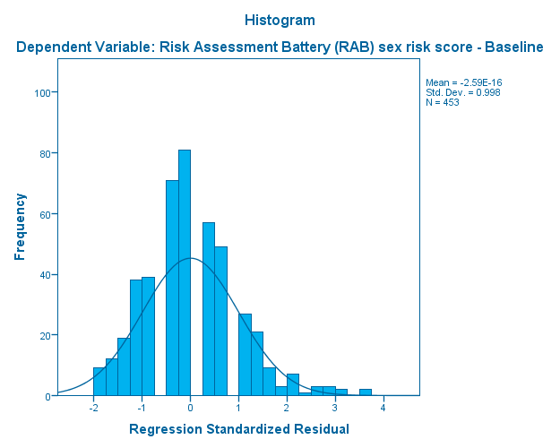

Charts  
Charts - *zresid Normal P-P Plot - October 17, 2017

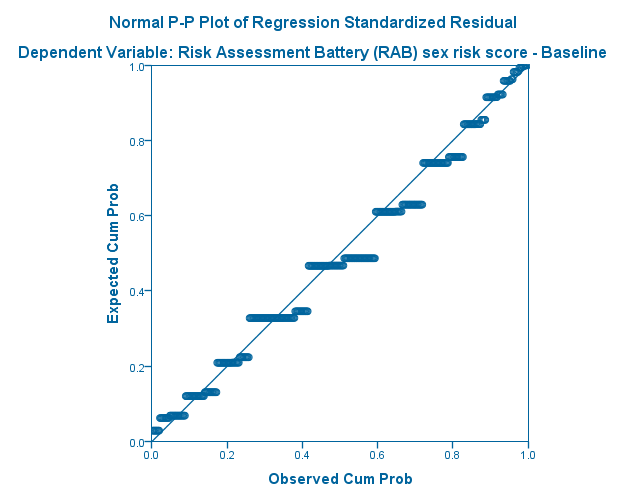

Log  
Log - Log - October 17, 2017

* ==========================================  
* try with otherhisp as reference category  
* so put race_black and race_white in the model  
*  
* look at intercept term and compare to mean sexrisk  
* for the otherhisp race...  
* ==========================================.  
REGRESSION  
/DESCRIPTIVES MEAN STDDEV CORR SIG N  
/MISSING LISTWISE  
/STATISTICS COEFF OUTS CI(95) R ANOVA CHANGE  
/CRITERIA=PIN(.05) POUT(.10)  
/NOORIGIN  
/DEPENDENT sexrisk  
/METHOD=ENTER race_black race_white  
/RESIDUALS HISTOGRAM(ZRESID) NORMPROB(ZRESID).

Regression  
Regression - Descriptive Statistics - October 17, 2017

Descriptive StatisticsDescriptive Statistics, table, 1 levels of column headers and 1 levels of row headers, table with 4 columns and 5 rows

|  | Mean | Std. Deviation | N |
| --- | --- | --- | --- |
| sexrisk Risk Assessment Battery (RAB) sex risk score - Baseline | 4.64 | 2.800 | 453 |
| race_black | .4658 | .49938 | 453 |
| race_white | .3664 | .48237 | 453 |

Regression  
Regression - Correlations - October 17, 2017

CorrelationsCorrelations, table, 1 levels of column headers and 2 levels of row headers, table with 5 columns and 11 rows

|  |  | sexrisk Risk Assessment Battery (RAB) sex risk score - Baseline | race_black | race_white |
| --- | --- | --- | --- | --- |
| Pearson Correlation | sexrisk Risk Assessment Battery (RAB) sex risk score - Baseline | 1.000 | .195 | -.150 |
|  | race_black | .195 | 1.000 | -.710 |
|  | race_white | -.150 | -.710 | 1.000 |
| Sig. (1-tailed) | sexrisk Risk Assessment Battery (RAB) sex risk score - Baseline | . | .000 | .001 |
|  | race_black | .000 | . | .000 |
|  | race_white | .001 | .000 | . |
| N | sexrisk Risk Assessment Battery (RAB) sex risk score - Baseline | 453 | 453 | 453 |
|  | race_black | 453 | 453 | 453 |
|  | race_white | 453 | 453 | 453 |

Regression  
Regression - Variables Entered/Removed - October 17, 2017

Variables Entered/Removed<sup>a</sup>Variables Entered/Removed, table, 1 levels of column headers and 1 levels of row headers, table with 4 columns and 5 rows

| Model | Variables Entered | Variables Removed | Method |
| --- | --- | --- | --- |
| 1 | race_white, race_black<sup>b</sup> | . | Enter |

a. Dependent Variable: sexrisk Risk Assessment Battery (RAB) sex risk score - Baseline  
b. All requested variables entered.

Regression  
Regression - Model Summary - October 17, 2017

Model Summary<sup>b</sup>Model Summary, table, 2 levels of column headers and 1 levels of row headers, table with 10 columns and 6 rows

| Model | R | R Square | Adjusted R Square | Std. Error of the Estimate | Change Statistics |  |  |  |  |
| --- | --- | --- | --- | --- | --- | --- | --- | --- | --- |
|  |  |  |  |  | R Square Change | F Change | df1 | df2 | Sig. F Change |
| 1 | .196<sup>a</sup> | .038 | .034 | 2.752 | .038 | 8.989 | 2 | 450 | .000 |

a. Predictors: (Constant), race_white, race_black  
b. Dependent Variable: sexrisk Risk Assessment Battery (RAB) sex risk score - Baseline

Regression  
Regression - ANOVA - October 17, 2017

ANOVA<sup>a</sup>ANOVA, table, 1 levels of column headers and 2 levels of row headers, table with 7 columns and 7 rows

| Model |  | Sum of Squares | df | Mean Square | F | Sig. |
| --- | --- | --- | --- | --- | --- | --- |
| 1 | Regression | 136.144 | 2 | 68.072 | 8.989 | .000<sup>b</sup> |
|  | Residual | 3407.923 | 450 | 7.573 |  |  |
|  | Total | 3544.066 | 452 |  |  |  |

a. Dependent Variable: sexrisk Risk Assessment Battery (RAB) sex risk score - Baseline  
b. Predictors: (Constant), race_white, race_black

Regression  
Regression - Coefficients - October 17, 2017

Coefficients<sup>a</sup>Coefficients, table, 2 levels of column headers and 2 levels of row headers, table with 9 columns and 7 rows

| Model |  | Unstandardized Coefficients |  | Standardized Coefficients | t | Sig. | 95.0% Confidence Interval for B |  |
| --- | --- | --- | --- | --- | --- | --- | --- | --- |
|  |  | B | Std. Error | Beta |  |  | Lower Bound | Upper Bound |
| 1 | (Constant) | 4.224 | .316 |  | 13.380 | .000 | 3.603 | 4.844 |
|  | race_black | 1.004 | .368 | .179 | 2.727 | .007 | .280 | 1.727 |
|  | race_white | -.133 | .381 | -.023 | -.350 | .727 | -.882 | .616 |

a. Dependent Variable: sexrisk Risk Assessment Battery (RAB) sex risk score - Baseline

Regression  
Regression - Residuals Statistics - October 17, 2017

Residuals Statistics<sup>a</sup>Residuals Statistics, table, 1 levels of column headers and 1 levels of row headers, table with 6 columns and 7 rows

|  | Minimum | Maximum | Mean | Std. Deviation | N |
| --- | --- | --- | --- | --- | --- |
| Predicted Value | 4.09 | 5.23 | 4.64 | .549 | 453 |
| Residual | -5.227 | 9.910 | .000 | 2.746 | 453 |
| Std. Predicted Value | -1.006 | 1.066 | .000 | 1.000 | 453 |
| Std. Residual | -1.900 | 3.601 | .000 | .998 | 453 |

a. Dependent Variable: sexrisk Risk Assessment Battery (RAB) sex risk score - Baseline

Charts  
Charts - *zresid Histogram - October 17, 2017

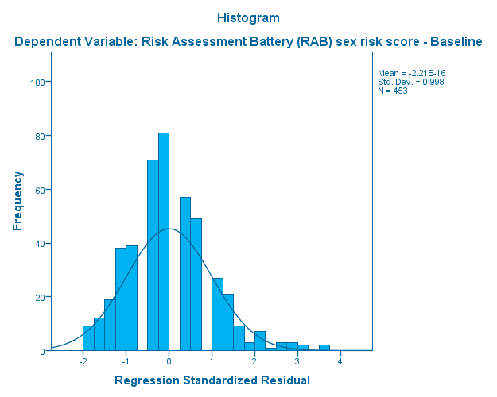

Charts  
Charts - *zresid Normal P-P Plot - October 17, 2017

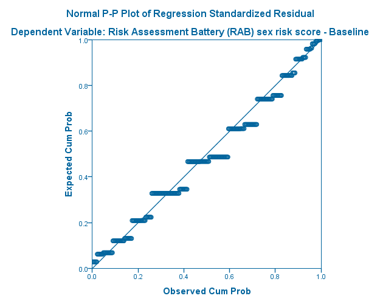

Log  
Log - Log - October 17, 2017

* ==========================================  
* comparing the GLM framework  
*  
* run racegrp3 as a FACTOR  
* we can manipulate how the comparisons are done  
* we can run post hoc tests  
* ==========================================.  
* Generalized Linear Models.  
GENLIN sexrisk BY racegrp3 (ORDER=ASCENDING)  
/MODEL racegrp3 INTERCEPT=YES  
DISTRIBUTION=NORMAL LINK=IDENTITY  
/CRITERIA SCALE=MLE COVB=MODEL PCONVERGE=1E-006(ABSOLUTE) SINGULAR=1E-012 ANALYSISTYPE=3(WALD)  
CILEVEL=95 CITYPE=WALD LIKELIHOOD=FULL  
/EMMEANS TABLES=racegrp3 SCALE=ORIGINAL COMPARE=racegrp3 CONTRAST=PAIRWISE PADJUST=LSD  
/MISSING CLASSMISSING=EXCLUDE  
/PRINT CPS DESCRIPTIVES MODELINFO FIT SUMMARY SOLUTION.

Generalized Linear Models  
Generalized Linear Models - Model Information - October 17, 2017

Model InformationModel Information, table, 0 levels of column headers and 1 levels of row headers, table with 2 columns and 4 rows

| Dependent Variable | sexrisk Risk Assessment Battery (RAB) sex risk score - Baseline |
| --- | --- |
| Probability Distribution | Normal |
| Link Function | Identity |

Generalized Linear Models  
Generalized Linear Models - Case Processing Summary - October 17, 2017

Case Processing SummaryCase Processing Summary, table, 1 levels of column headers and 1 levels of row headers, table with 3 columns and 5 rows

|  | N | Percent |
| --- | --- | --- |
| Included | 453 | 100.0% |
| Excluded | 0 | 0.0% |
| Total | 453 | 100.0% |

Generalized Linear Models  
Generalized Linear Models - Categorical Variable Information - October 17, 2017

Categorical Variable InformationCategorical Variable Information, table, 1 levels of column headers and 3 levels of row headers, table with 5 columns and 6 rows

|  |  |  | N | Percent |
| --- | --- | --- | --- | --- |
| Factor | racegrp3 Race 3 Groups | 1 black | 211 | 46.6% |
|  |  | 2 hispanic or other | 76 | 16.8% |
|  |  | 3 white | 166 | 36.6% |
|  |  | Total | 453 | 100.0% |

Generalized Linear Models  
Generalized Linear Models - Continuous Variable Information - October 17, 2017

Continuous Variable InformationContinuous Variable Information, table, 1 levels of column headers and 2 levels of row headers, table with 7 columns and 3 rows

|  |  | N | Minimum | Maximum | Mean | Std. Deviation |
| --- | --- | --- | --- | --- | --- | --- |
| Dependent Variable | sexrisk Risk Assessment Battery (RAB) sex risk score - Baseline | 453 | 0 | 14 | 4.64 | 2.800 |

Generalized Linear Models  
Generalized Linear Models - Goodness of Fit - October 17, 2017

Goodness of Fit<sup>a</sup>Goodness of Fit, table, 1 levels of column headers and 1 levels of row headers, table with 4 columns and 14 rows

|  | Value | df | Value/df |
| --- | --- | --- | --- |
| Deviance | 3407.923 | 450 | 7.573 |
| Scaled Deviance | 453.000 | 450 |  |
| Pearson Chi-Square | 3407.923 | 450 | 7.573 |
| Scaled Pearson Chi-Square | 453.000 | 450 |  |
| Log Likelihood<sup>b</sup> | -1099.848 |  |  |
| Akaike's Information Criterion (AIC) | 2207.697 |  |  |
| Finite Sample Corrected AIC (AICC) | 2207.786 |  |  |
| Bayesian Information Criterion (BIC) | 2224.160 |  |  |
| Consistent AIC (CAIC) | 2228.160 |  |  |

Dependent Variable: Risk Assessment Battery (RAB) sex risk score - Baseline Model: (Intercept), racegrp3  
a. Information criteria are in smaller-is-better form.  
b. The full log likelihood function is displayed and used in computing information criteria.

Generalized Linear Models  
Generalized Linear Models - Omnibus Test - October 17, 2017

Omnibus Test<sup>a</sup>Omnibus Test, table, 1 levels of column headers and 0 levels of row headers, table with 3 columns and 5 rows

| Likelihood Ratio Chi-Square | df | Sig. |
| --- | --- | --- |
| 17.745 | 2 | .000 |

Dependent Variable: Risk Assessment Battery (RAB) sex risk score - Baseline Model: (Intercept), racegrp3  
a. Compares the fitted model against the intercept-only model.

Generalized Linear Models  
Generalized Linear Models - Tests of Model Effects - October 17, 2017

Tests of Model EffectsTests of Model Effects, table, 2 levels of column headers and 1 levels of row headers, table with 4 columns and 6 rows

| Source | Type III |  |  |
| --- | --- | --- | --- |
|  | Wald Chi-Square | df | Sig. |
| (Intercept) | 1018.964 | 1 | .000 |
| racegrp3 | 18.097 | 2 | .000 |

Dependent Variable: Risk Assessment Battery (RAB) sex risk score - Baseline Model: (Intercept), racegrp3

Generalized Linear Models  
Generalized Linear Models - Parameter Estimates - October 17, 2017

Parameter EstimatesParameter Estimates, table, 2 levels of column headers and 1 levels of row headers, table with 8 columns and 11 rows

| Parameter | B | Std. Error | 95% Wald Confidence Interval |  | Hypothesis Test |  |  |
| --- | --- | --- | --- | --- | --- | --- | --- |
|  |  |  | Lower | Upper | Wald Chi-Square | df | Sig. |
| (Intercept) | 4.090 | .2129 | 3.673 | 4.508 | 369.182 | 1 | .000 |
| [racegrp3=1] | 1.137 | .2846 | .579 | 1.695 | 15.969 | 1 | .000 |
| [racegrp3=2] | .133 | .3799 | -.611 | .878 | .123 | 1 | .726 |
| [racegrp3=3] | 0<sup>a</sup> | . | . | . | . | . | . |
| (Scale) | 7.523<sup>b</sup> | .4999 | 6.604 | 8.569 |  |  |  |

Dependent Variable: Risk Assessment Battery (RAB) sex risk score - Baseline Model: (Intercept), racegrp3  
a. Set to zero because this parameter is redundant.  
b. Maximum likelihood estimate.

Estimated Marginal Means: racegrp3 Race 3 Groups  
Estimated Marginal Means: racegrp3 Race 3 Groups - Estimates - October 17, 2017

EstimatesEstimates, table, 2 levels of column headers and 1 levels of row headers, table with 5 columns and 6 rows

| racegrp3 Race 3 Groups | Mean | Std. Error | 95% Wald Confidence Interval |  |
| --- | --- | --- | --- | --- |
|  |  |  | Lower | Upper |
| 1 black | 5.23 | .189 | 4.86 | 5.60 |
| 2 hispanic or other | 4.22 | .315 | 3.61 | 4.84 |
| 3 white | 4.09 | .213 | 3.67 | 4.51 |

Estimated Marginal Means: racegrp3 Race 3 Groups  
Estimated Marginal Means: racegrp3 Race 3 Groups - Pairwise Comparisons - October 17, 2017

Pairwise ComparisonsPairwise Comparisons, table, 2 levels of column headers and 2 levels of row headers, table with 8 columns and 11 rows

| (I) racegrp3 Race 3 Groups | (J) racegrp3 Race 3 Groups | Mean Difference (I-J) | Std. Error | df | Sig. | 95% Wald Confidence Interval for Difference |  |
| --- | --- | --- | --- | --- | --- | --- | --- |
|  |  |  |  |  |  | Lower | Upper |
| 1 black | 2 hispanic or other | 1.00<sup>a</sup> | .367 | 1 | .006 | .28 | 1.72 |
|  | 3 white | 1.14<sup>a</sup> | .285 | 1 | .000 | .58 | 1.69 |
| 2 hispanic or other | 1 black | -1.00<sup>a</sup> | .367 | 1 | .006 | -1.72 | -.28 |
|  | 3 white | .13 | .380 | 1 | .726 | -.61 | .88 |
| 3 white | 1 black | -1.14<sup>a</sup> | .285 | 1 | .000 | -1.69 | -.58 |
|  | 2 hispanic or other | -.13 | .380 | 1 | .726 | -.88 | .61 |

Pairwise comparisons of estimated marginal means based on the original scale of dependent variable sexrisk Risk Assessment Battery (RAB) sex risk score - Baseline  
a. The mean difference is significant at the .05 level.

Estimated Marginal Means: racegrp3 Race 3 Groups  
Estimated Marginal Means: racegrp3 Race 3 Groups - Overall Test Results - October 17, 2017

Overall Test ResultsOverall Test Results, table, 1 levels of column headers and 0 levels of row headers, table with 3 columns and 4 rows

| Wald Chi-Square | df | Sig. |
| --- | --- | --- |
| 18.097 | 2 | .000 |

The Wald chi-square tests the effect of racegrp3 Race 3 Groups. This test is based on the linearly independent pairwise comparisons among the estimated marginal means.

Log  
Log - Log - October 17, 2017

* ==========================================  
* run racegrp3 as a COVARIATE  
* treats racegrp3 as a continuous/ordinal variable  
* so the slope coefficient looks at changes from  
* black to otherhisp to white which might not be what you want  
* ==========================================.  
* Generalized Linear Models.  
GENLIN sexrisk WITH racegrp3  
/MODEL racegrp3 INTERCEPT=YES  
DISTRIBUTION=NORMAL LINK=IDENTITY  
/CRITERIA SCALE=MLE COVB=MODEL PCONVERGE=1E-006(ABSOLUTE) SINGULAR=1E-012 ANALYSISTYPE=3(WALD)  
CILEVEL=95 CITYPE=WALD LIKELIHOOD=FULL  
/MISSING CLASSMISSING=EXCLUDE  
/PRINT CPS DESCRIPTIVES MODELINFO FIT SUMMARY SOLUTION.

Generalized Linear Models  
Generalized Linear Models - Model Information - October 17, 2017

Model InformationModel Information, table, 0 levels of column headers and 1 levels of row headers, table with 2 columns and 4 rows

| Dependent Variable | sexrisk Risk Assessment Battery (RAB) sex risk score - Baseline |
| --- | --- |
| Probability Distribution | Normal |
| Link Function | Identity |

Generalized Linear Models  
Generalized Linear Models - Case Processing Summary - October 17, 2017

Case Processing SummaryCase Processing Summary, table, 1 levels of column headers and 1 levels of row headers, table with 3 columns and 5 rows

|  | N | Percent |
| --- | --- | --- |
| Included | 453 | 100.0% |
| Excluded | 0 | 0.0% |
| Total | 453 | 100.0% |

Generalized Linear Models  
Generalized Linear Models - Continuous Variable Information - October 17, 2017

Continuous Variable InformationContinuous Variable Information, table, 1 levels of column headers and 2 levels of row headers, table with 7 columns and 4 rows

|  |  | N | Minimum | Maximum | Mean | Std. Deviation |
| --- | --- | --- | --- | --- | --- | --- |
| Dependent Variable | sexrisk Risk Assessment Battery (RAB) sex risk score - Baseline | 453 | 0 | 14 | 4.64 | 2.800 |
| Covariate | racegrp3 Race 3 Groups | 453 | 1 | 3 | 1.90 | .908 |

Generalized Linear Models  
Generalized Linear Models - Goodness of Fit - October 17, 2017

Goodness of Fit<sup>a</sup>Goodness of Fit, table, 1 levels of column headers and 1 levels of row headers, table with 4 columns and 14 rows

|  | Value | df | Value/df |
| --- | --- | --- | --- |
| Deviance | 3419.875 | 451 | 7.583 |
| Scaled Deviance | 453.000 | 451 |  |
| Pearson Chi-Square | 3419.875 | 451 | 7.583 |
| Scaled Pearson Chi-Square | 453.000 | 451 |  |
| Log Likelihood<sup>b</sup> | -1100.641 |  |  |
| Akaike's Information Criterion (AIC) | 2207.283 |  |  |
| Finite Sample Corrected AIC (AICC) | 2207.336 |  |  |
| Bayesian Information Criterion (BIC) | 2219.631 |  |  |
| Consistent AIC (CAIC) | 2222.631 |  |  |

Dependent Variable: Risk Assessment Battery (RAB) sex risk score - Baseline Model: (Intercept), racegrp3  
a. Information criteria are in smaller-is-better form.  
b. The full log likelihood function is displayed and used in computing information criteria.

Generalized Linear Models  
Generalized Linear Models - Omnibus Test - October 17, 2017

Omnibus Test<sup>a</sup>Omnibus Test, table, 1 levels of column headers and 0 levels of row headers, table with 3 columns and 5 rows

| Likelihood Ratio Chi-Square | df | Sig. |
| --- | --- | --- |
| 16.159 | 1 | .000 |

Dependent Variable: Risk Assessment Battery (RAB) sex risk score - Baseline Model: (Intercept), racegrp3  
a. Compares the fitted model against the intercept-only model.

Generalized Linear Models  
Generalized Linear Models - Tests of Model Effects - October 17, 2017

Tests of Model EffectsTests of Model Effects, table, 2 levels of column headers and 1 levels of row headers, table with 4 columns and 6 rows

| Source | Type III |  |  |
| --- | --- | --- | --- |
|  | Wald Chi-Square | df | Sig. |
| (Intercept) | 366.573 | 1 | .000 |
| racegrp3 | 16.450 | 1 | .000 |

Dependent Variable: Risk Assessment Battery (RAB) sex risk score - Baseline Model: (Intercept), racegrp3

Generalized Linear Models  
Generalized Linear Models - Parameter Estimates - October 17, 2017

Parameter EstimatesParameter Estimates, table, 2 levels of column headers and 1 levels of row headers, table with 8 columns and 8 rows

| Parameter | B | Std. Error | 95% Wald Confidence Interval |  | Hypothesis Test |  |  |
| --- | --- | --- | --- | --- | --- | --- | --- |
|  |  |  | Lower | Upper | Wald Chi-Square | df | Sig. |
| (Intercept) | 5.740 | .2998 | 5.152 | 6.327 | 366.573 | 1 | .000 |
| racegrp3 | -.577 | .1424 | -.856 | -.298 | 16.450 | 1 | .000 |
| (Scale) | 7.549<sup>a</sup> | .5016 | 6.628 | 8.599 |  |  |  |

Dependent Variable: Risk Assessment Battery (RAB) sex risk score - Baseline Model: (Intercept), racegrp3  
a. Maximum likelihood estimate.

Log  
Log - Log - October 17, 2017

* ==========================================  
* compare the MAIN EFFECT for racegrp3 here  
* between these 2 models.  
*  
* pay attention to the degrees of freedom and the kind of  
* test that is being performed...  
* ==========================================.

[output not shown]

[output not shown]

[output not shown]

[output not shown]

[output not shown]

[output not shown]